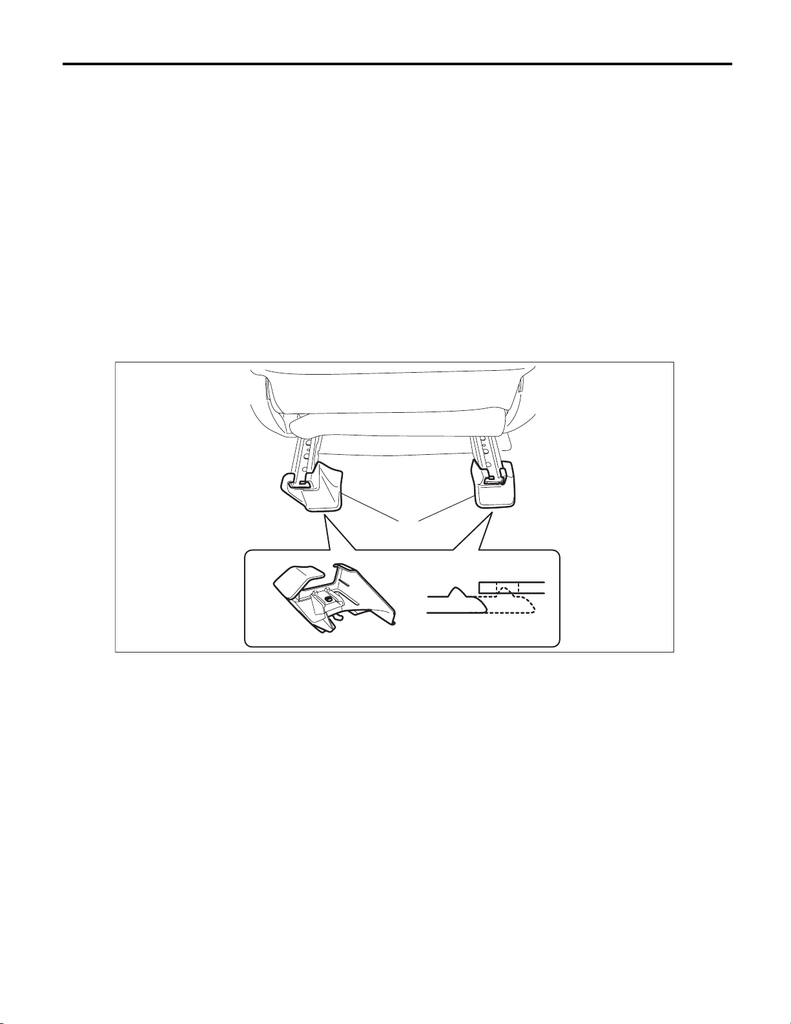

SE-9

Front Seat

SEATS

2. Front Seat

A: REMOVAL

CAUTION:

The airbag system is fitted with a backup power supply. After disconnecting the battery ground ca-

ble, the airbag may operate if you do not wait for 60 seconds before starting the service of airbag sys-

tem.

1) Remove the headrest assembly - front.

2) Disconnect the ground cable from battery and wait for at least 60 seconds before starting work. <Ref. to

NT-5, BATTERY, NOTE, Note.>

NOTE:

• For models other than STI model, disconnect the ground terminal from battery sensor.

• On CVT models, shift the select lever into “D” before disconnecting the battery ground cable.

• For the power seat, remove the slide rail installing bolt before removing the battery ground.

3) Remove the slide rail assembly installing bolt.

(1) Tilt the backrest assembly forward and move the front seat to the front most position.

(2) Remove the cover - bolt rear (A) and remove the bolts.

(3) Move the front seat to the rearmost position, and remove the bolts.

4) Disconnect the connector under the front seat.

• Seat belt warning light connector (driver’s seat)

• Occupant detection system harness connector (passenger’s seat) <Ref. to OD(diag)-9, OCCUPANT DE-

TECTION SYSTEM (BETWEEN AIRBAG REAR HARNESS AND SEAT HARNESS), PROCEDURE, Airbag

Connector.>

• Side airbag connector <Ref. to AB-23, SIDE AIRBAG MODULE, PROCEDURE, Airbag Connector.>

• Seat heater connector (model with seat heater)

• Buckle switch RH connector (passenger’s seat) <Ref. to AB-24, BUCKLE SWITCH RH, PROCEDURE,

Airbag Connector.>

5) Take out the front seat from the vehicle.

CAUTION:

Be careful not to damage the body.

(A)

SE-01296

15WRX_STI_US_EN.book 9 ページ ２０１５年２月１３日 金曜日 午前１１時２０分

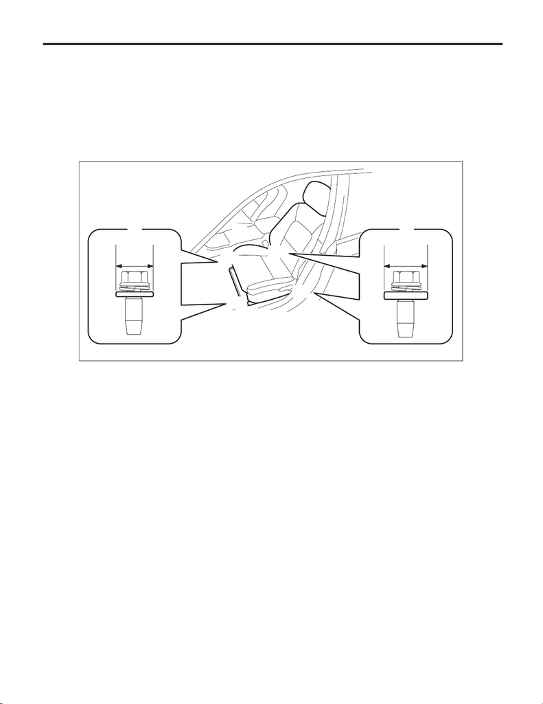

SE-10

Front Seat

SEATS

B: INSTALLATION

1) Bring the front seat inside the vehicle.

2) Connect the connectors located under the front seat.

3) Install the seat assembly.

CAUTION:

• The front seat mounting bolts differ between the front mounting points and the rear mounting

points. When installing the front seat, make sure that you are using correct bolts at correct positions.

• Tighten the slide rail assembly installing bolts in the order as shown in the figure, in several steps

by gradually increasing the torque until they reach the specified torque.

• Front (bolt A): Washer diameter 22 mm (0.87 in)

• Rear (bolt B): Washer diameter 26 mm (1.02 in)

Tightening torque:

Front seat assembly: 53 N·m (5.4 kgf-m, 39.1 ft-lb)

4) Connect the battery ground terminal. <Ref. to NT-5, BATTERY, NOTE, Note.>

NOTE:

For models other than STI model, connect the ground terminal to battery sensor.

5) Install the headrest assembly - front.

SE-01116

(2)

(3)

(4)

A

22 mm

(0.87 in)

26 mm

(1.02 in)

B

(1)

15WRX_STI_US_EN.book 10 ページ ２０１５年２月１３日 金曜日 午前１１時２０分

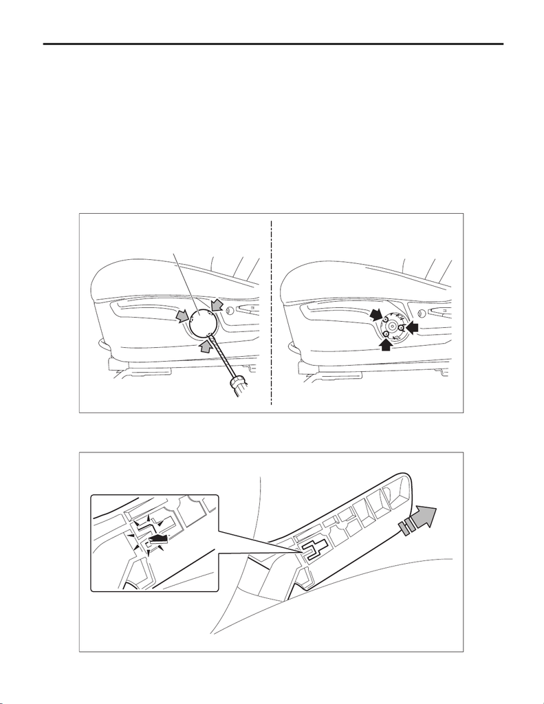

SE-11

Front Seat

SEATS

C: DISASSEMBLY

1. MANUAL SEAT

CAUTION:

Before assembling, make sure how the harnesses such as the side airbag harness and the seat belt

inner - front harness are routed in order to avoid misarranging. Assembling with harnesses improp-

erly routed may cause the harness to get caught and short out.

1) Remove the front seat from vehicle. <Ref. to SE-9, REMOVAL, Front Seat.>

2) Remove the knob - lifter.

(1) Remove the cap - lifter lever (a).

NOTE:

Insert a flat tip screwdriver or similar tool wrapped with protective tape into the gap (shown with arrow) be-

tween the cap - lifter lever and the knob - lifter.

(2) Remove the screws and remove the knob - lifter.

3) Remove the lever - reclining.

(1) Pull up the lever - reclining and release the claws on the back.

(2) Pull out the lever - reclining.

SE-01671

(a)

SE-01101

15WRX_STI_US_EN.book 11 ページ ２０１５年２月１３日 金曜日 午前１１時２０分

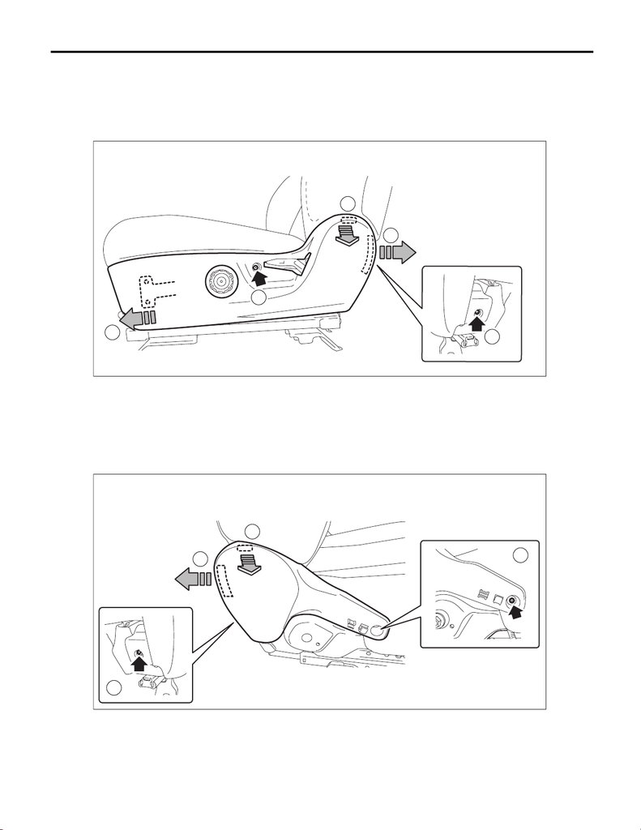

SE-12

Front Seat

SEATS

4) Remove the cover - hinge front seat OUT.

(1) Remove the screws.

(2) Release the claw in the upper section of the cover - hinge front seat OUT.

(3) Release the claw in the rear section of the cover - hinge front seat OUT.

(4) Release the claw in the front section of the cover - hinge front seat OUT, then remove the cover -

hinge front seat OUT.

5) Remove the seat belt inner - front. <Ref. to SB-17, SEAT BELT INNER - FRONT, REMOVAL, Front Seat

Belt.>

6) Remove the cover - hinge front seat INN.

(1) Remove the screws.

(2) Release the claw in the upper section of the cover - hinge front seat INN.

(3) Release the claw in the rear section of the cover - hinge front seat INN, then remove the cover - hinge

front seat INN.

SE-01667

4

1

2

3

1

SE-01299

1

1

2

3

15WRX_STI_US_EN.book 12 ページ ２０１５年２月１３日 金曜日 午前１１時２０分

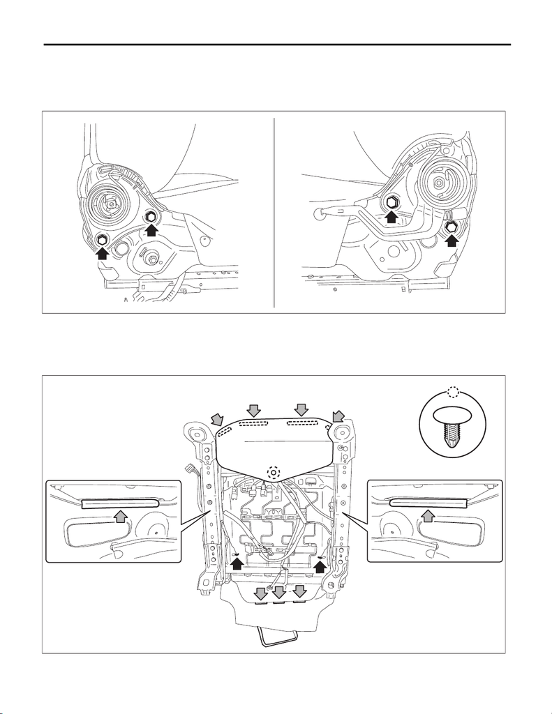

SE-13

Front Seat

SEATS

7) Separate the backrest assembly and the seat cushion assembly.

(1) Remove the clip for the side airbag harness located under the seat cushion assembly.

(2) Remove the bolts from reclining hinge of both sides.

(3) While taking care not to damage the airbag harness, separate the backrest assembly and the seat

cushion assembly.

8) Remove the pad assembly - front seat cushion and the cover - front cushion.

(1) Remove the rubber band and clips.

(2) Remove the hooks and hog rings.

(3) Remove the pad assembly - front seat cushion and the cover - front cushion from the seat cushion as-

sembly.

SE-01300

SE-01668

15WRX_STI_US_EN.book 13 ページ ２０１５年２月１３日 金曜日 午前１１時２０分

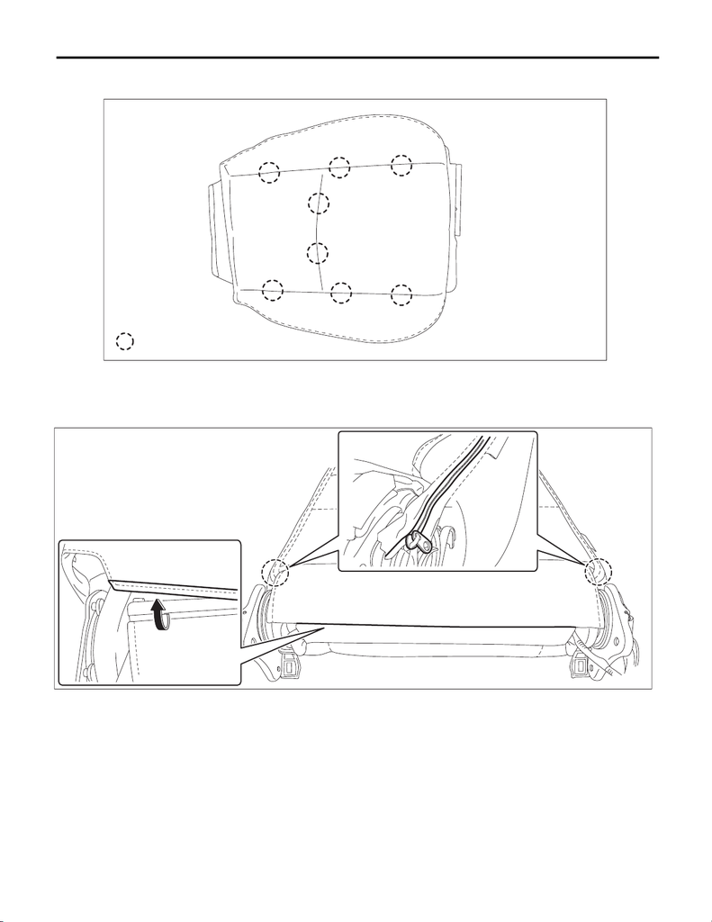

SE-14

Front Seat

SEATS

9) Remove the cover - front cushion.

(1) Remove the hog ring (A).

(2) Pull out the pad assembly - front seat cushion from the cover - front cushion.

10) Remove the pad assembly - front seat backrest and the cover COMPL - front backrest.

(1) Remove the plastic fastener at the back side (bottom) of backrest assembly.

(2) Open the fastener at the rear side of backrest assembly.

SE-01302

A:

SE-01332

15WRX_STI_US_EN.book 14 ページ ２０１５年２月１３日 金曜日 午前１１時２０分

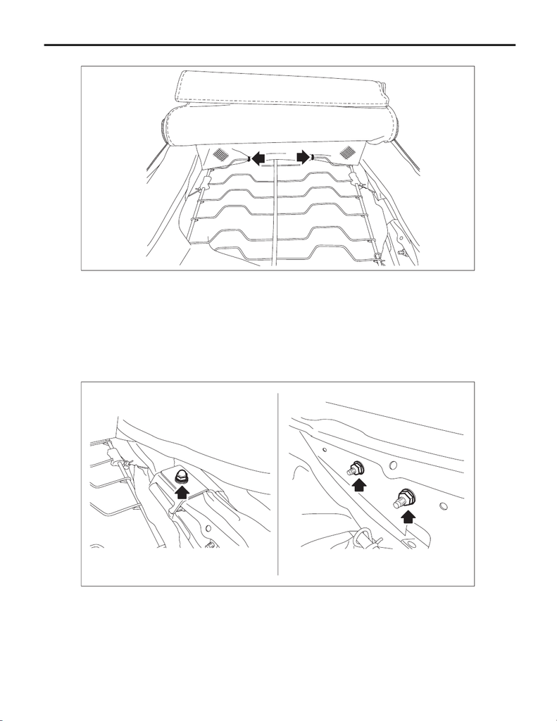

SE-15

Front Seat

SEATS

(3) Remove the hog ring.

(4) Remove the pad assembly - front seat backrest and the cover COMPL - front backrest from the back-

rest assembly.

11) Remove the side airbag module.

CAUTION:

Do not open the protective cover of the side airbag. If any damage is present in the protective cover

or the cloth of side airbag module comes out from the protective cover slit, replace the side airbag

module with a new part.

(1) Remove the hexagon cap nut and nuts.

(2) While taking care not to damage the airbag protective cover, remove the side airbag module.

SE-01635

SE-01304

15WRX_STI_US_EN.book 15 ページ ２０１５年２月１３日 金曜日 午前１１時２０分

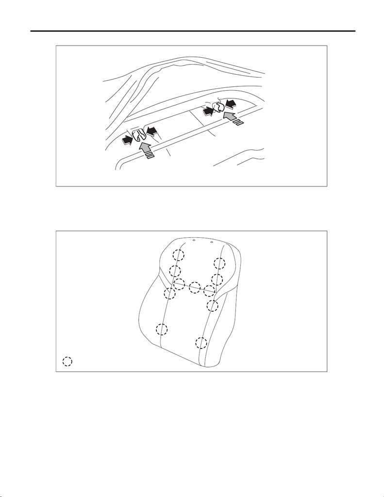

SE-16

Front Seat

SEATS

12) Remove the bushing - headrest.

NOTE:

Catch the tip of the bushing - headrest with pliers and push it outward from the inside of seat to remove it.

13) Pull out the frame assembly - front backrest.

14) Remove the cover COMPL - front backrest.

(1) Remove the hog ring (A).

(2) Pull out the pad assembly - front seat backrest from the cover COMPL - front backrest.

SE-01003

SE-01697

A:

15WRX_STI_US_EN.book 16 ページ ２０１５年２月１３日 金曜日 午前１１時２０分

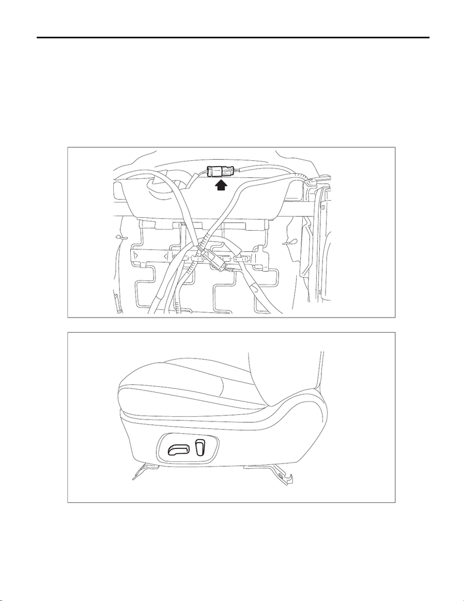

SE-17

Front Seat

SEATS

2. POWER SEAT

CAUTION:

• Before assembling, make sure how the harnesses such as the side airbag harness and the seat

belt inner - front harness are routed in order to avoid misarranging. Assembling with harnesses im-

properly routed may cause the harness to get caught and short out.

1) Remove the seat from vehicle. <Ref. to SE-9, REMOVAL, Front Seat.>

NOTE:

Before removing the seat, raise the seating face.

2) Disconnect the connector for reclining motor from the backside of seat cushion.

3) Remove the knob - power seat.

SE-01339

SE-01336

15WRX_STI_US_EN.book 17 ページ ２０１５年２月１３日 金曜日 午前１１時２０分

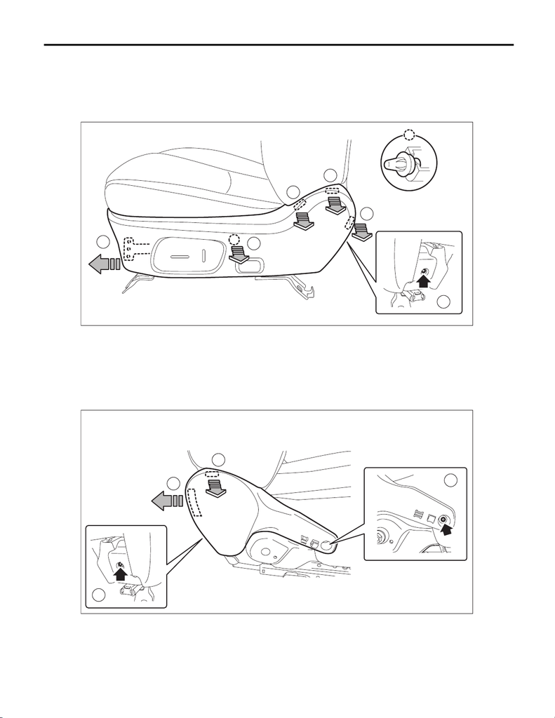

SE-18

Front Seat

SEATS

4) Remove the cover - hinge front seat OUT.

(1) Remove the screws in the rear section of the cover - hinge front seat OUT.

(2) Release the claw in the upper section of the cover - hinge front seat OUT.

(3) Remove the clip, and release the claws in the front section of the cover - hinge front seat OUT.

(4) Disconnect the power seat switch and lumber switch connector and remove the cover - hinge front

seat OUT.

5) Remove the seat belt inner - front. <Ref. to SB-17, SEAT BELT INNER - FRONT, REMOVAL, Front Seat

Belt.>

6) Remove the cover - hinge front seat INN.

(1) Remove the screws.

(3) Release the claw in the rear section of the cover - hinge front seat INN.

SE-01669

4

3

1

2

2

2

SE-01299

1

1

2

3

15WRX_STI_US_EN.book 18 ページ ２０１５年２月１３日 金曜日 午前１１時２０分

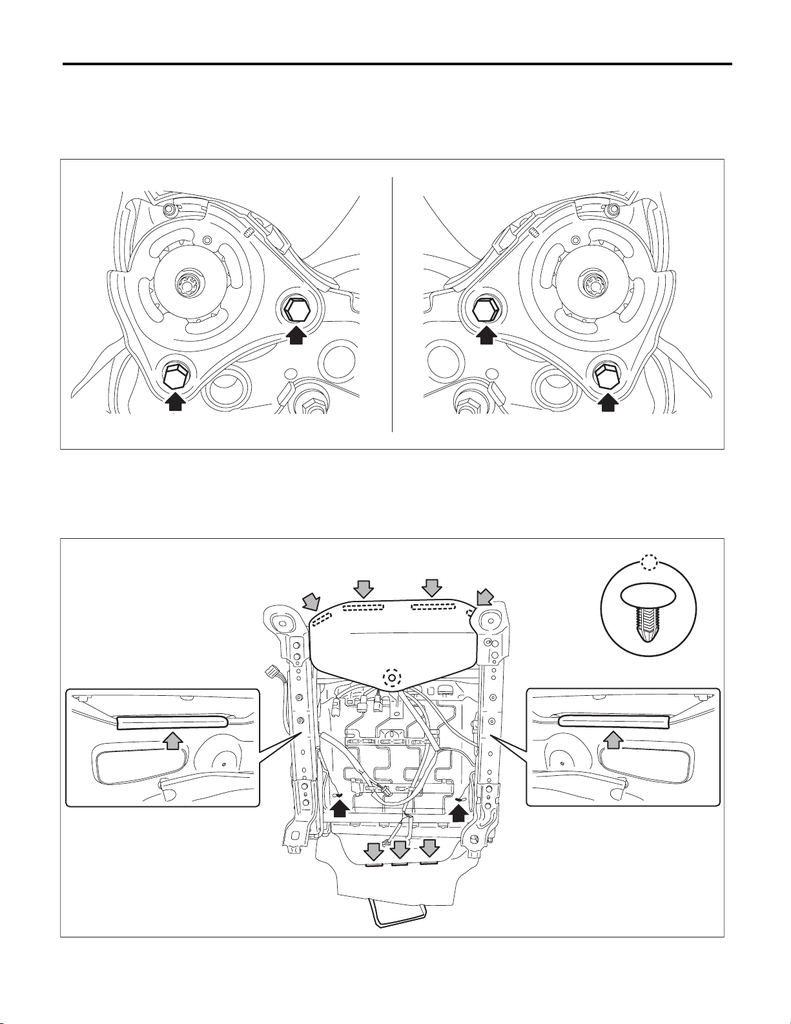

SE-19

Front Seat

SEATS

7) Separate the backrest assembly and the seat cushion assembly.

(1) Remove the clip for the side airbag harness located under the seat cushion assembly.

(2) Remove the bolts from reclining hinge of both sides.

(3) While taking care not to damage the airbag harness, separate the backrest assembly and the seat

cushion assembly.

8) Remove the pad assembly - front seat cushion and the cover - front cushion.

(1) Remove the rubber band and clips.

(2) Remove the hooks and hog rings.

(3) Remove the pad assembly - front seat cushion and the cover - front cushion from the seat cushion as-

sembly.

SE-01341

SE-01668

15WRX_STI_US_EN.book 19 ページ ２０１５年２月１３日 金曜日 午前１１時２０分

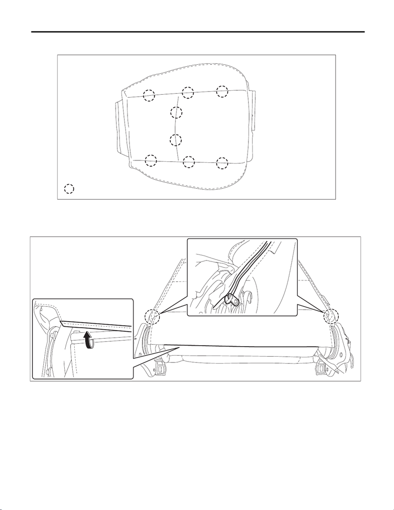

SE-20

Front Seat

SEATS

9) Remove the cover - front cushion.

(1) Remove the hog ring (A).

(2) Pull out the pad assembly - front seat cushion from the cover - front cushion.

10) Remove the pad assembly - front seat backrest and the cover COMPL - front backrest.

(1) Remove the plastic fastener at the back side (bottom) of backrest assembly.

(2) Open the fastener at the rear side of backrest assembly.

SE-01302

A:

SE-01332

15WRX_STI_US_EN.book 20 ページ ２０１５年２月１３日 金曜日 午前１１時２０分

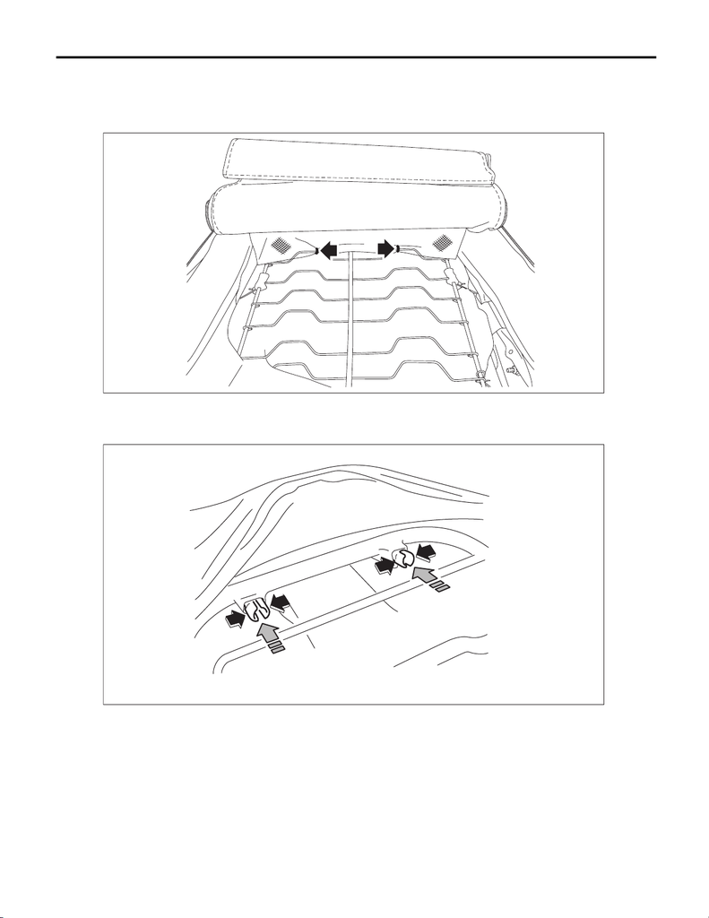

SE-21

Front Seat

SEATS

(3) Remove the hog ring.

CAUTION:

Be careful not to tear the vinyl inside the seat when removing the hog rings.

If torn, replace with a new part.

(4) Remove the backrest pad & cover from backrest assembly.

11) Remove the side airbag module. <Ref. to AB-43, REMOVAL, Side Airbag Module.>

12) Remove the headrest bushing.

NOTE:

Catch the tip of headrest bushing with pliers and push it from inside seat to outside to remove it.

13) Pull out the frame assembly - front backrest.

SE-01635

SE-01003

15WRX_STI_US_EN.book 21 ページ ２０１５年２月１３日 金曜日 午前１１時２０分

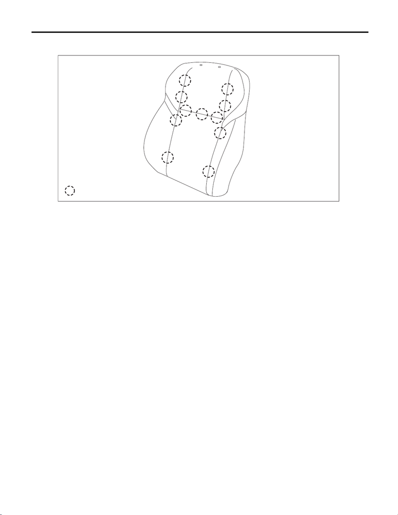

SE-22

Front Seat

SEATS

14) Remove the cover COMPL - front backrest.

(1) Remove the hog ring (A).

(2) Pull out the pad assembly - front seat backrest from the cover COMPL - front backrest.

3. PASSENGER’S SEAT

CAUTION:

• The occupant detection system (passenger’s seat only) control module, the occupant detection

sensor, the pad assembly - front seat cushion and the frame assembly - front cushion are considered

as a single seat cushion pad & frame assembly. Never remove the occupant detection control mod-

ule or the occupant detection sensor from the frame assembly - front cushion.

• If the cover - front cushion is removed, make sure to replace the hang wire on the cover - front

cushion side with a new wire.

• Never remove the occupant detection sensor connector from the occupant detection control mod-

ule.

• When replacing the seat cover, be careful not to damage the occupant detection sensor while in-

stalling the hog ring.

• When removing or replacing the seat cover, perform “Occupant Detection System Inspection” af-

ter installing the seat to check if the occupant detection system operates normally. <Ref. to PI-22,

SEAT, PRE-DELIVERY INSPECTION (PDI) PROCEDURE, Pre-delivery Inspection.>

1) Remove the front seat (passenger’s side) from vehicle. <Ref. to SE-9, REMOVAL, Front Seat.>

2) Refer to the disassembly procedures for the driver’s seat. <Ref. to SE-11, MANUAL SEAT, DISASSEM-

BLY, Front Seat.>

SE-01697

A:

15WRX_STI_US_EN.book 22 ページ ２０１５年２月１３日 金曜日 午前１１時２０分

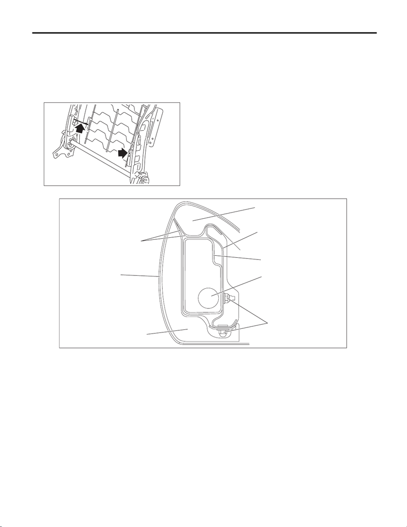

SE-23

Front Seat

SEATS

D: ASSEMBLY

CAUTION:

• Do not confuse the harness routing of the side airbag harness and the seat belt inner - front har-

ness, etc. Assembling with harnesses improperly routed may cause the harness to get caught and

short out.

• If the flat mat hook of the frame assembly - front backrest is deformed or comes off due to the de-

formation, replace the hook with a new part.

• Make sure that the side airbag module is installed as shown in the figure.

Besides, if the cover COMPL - front backrest is not installed securely, the side airbag may not be ac-

tivated properly, therefore keep strictly to the following procedures.

• Be careful not to stain or damage the cover COMPL - front backrest during assembly.

• Do not reuse hog rings.

• Secure the hog ring using hog ring pliers.

• Install the hog rings to the specified points securely and make sure that there is no wrinkle or twist-

ing on the cover COMPL - front backrest.

1) Make sure that there is no foreign matter on side airbag module.

SE-00964

(1) Pad ASSY - front seat backrest (4) Side airbag module inflator (7) Side airbag guide cloth

(2) Frame ASSY - front backrest (5) Nut

(3) Side airbag module protective

cover

(6) Cover COMPL - front backrest

SE-01335

(1)

(1)

(2)

(3)

(4)

(5)

(6)

(7)

15WRX_STI_US_EN.book 23 ページ ２０１５年２月１３日 金曜日 午前１１時２０分

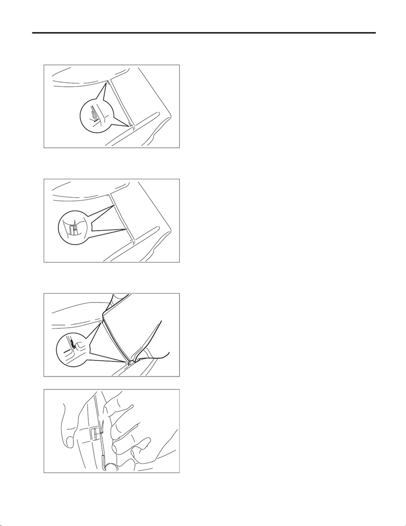

SE-24

Front Seat

SEATS

2) Assemble the seat cover.

(1) Adjust so that the left and right clearances between wire and seat pad become equal, and mark the

seat pad.

(2) Mark the center of the wire on the pad side to which the hog ring is attached.

(3) Insert the wire into the seat cover, and align the wire with the position marked in step 1).

(4) Mark the wire on the seat cover side according to the markings on the seat pad.

SE-01372

(1)

(1) Marking

SE-01373

(1)

(1) Marking

SE-01374

SE-01262

(1)

(1) Marking

15WRX_STI_US_EN.book 24 ページ ２０１５年２月１３日 金曜日 午前１１時２０分

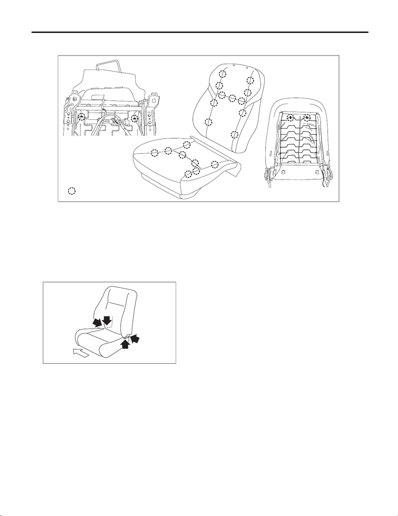

SE-25

Front Seat

SEATS

(5) Perform steps 1) — 4) to all sections to which the hog rings are attached.

(6) Make sure that all hog rings (A) are attached securely.

3) Assemble remaining parts in the reverse order of disassemble.

NOTE:

• When installing the seat belt inner - front, follow the procedures described in the seat belt section. <Ref.

to SB-19, INSTALLATION, Front Seat Belt.>

• Install the backrest assembly and seat cushion assembly in the following procedure.

1. Temporarily tighten the four reclining hinge bolts.

2. Place the backrest in the most upright position.

3. Tighten the reclining hinge bolts in order from (1) to (4) two or three times, until they reach the specified

torque.

Tightening torque:

Refer to “COMPONENT” of “General Description”. <Ref. to SE-2, FRONT SEAT, COMPONENT,

General Description.>

SE-01698

(A):

(A)

(B)

(2)

(4)

(3)

(1)

SE-00514

(A) Vehicle inside

(B) Vehicle outside

15WRX_STI_US_EN.book 25 ページ ２０１５年２月１３日 金曜日 午前１１時２０分

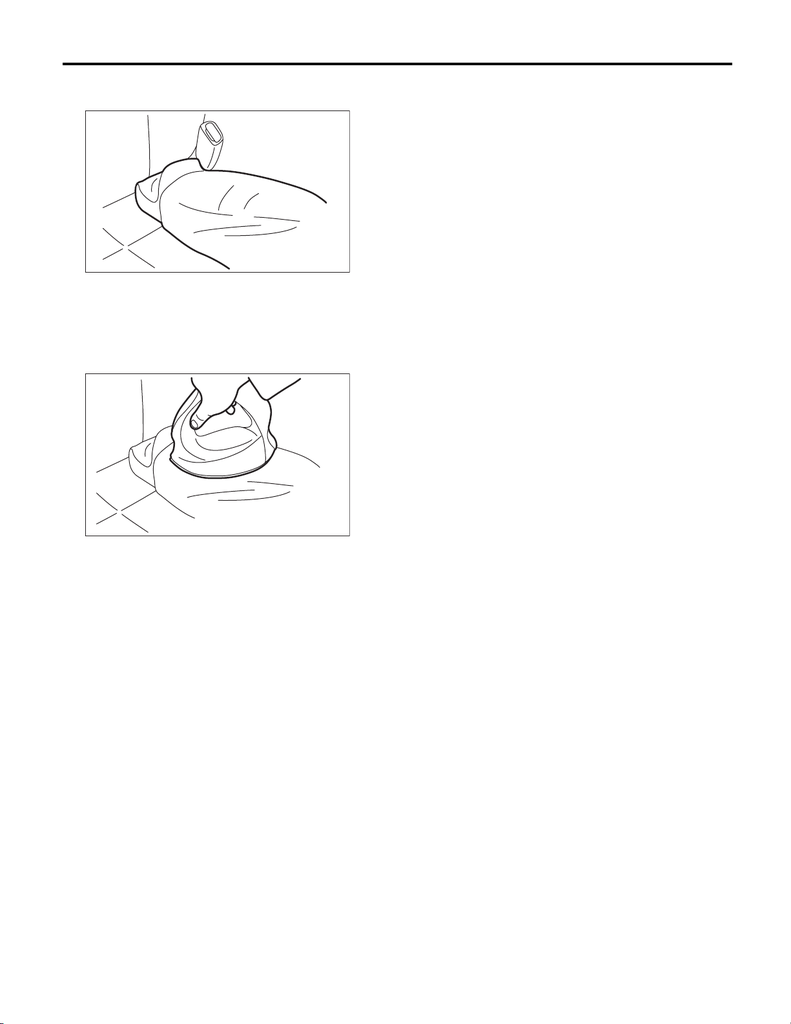

SE-26

Front Seat

SEATS

4) If any wrinkles are found after the assembly of the seat cover, finish the seat cover with iron.

(1) Place the wet towel on wrinkles.

(2) Touch up with warm iron.

CAUTION:

Keep moving the iron, otherwise the seat cover surface can be damaged.

NOTE:

SE-01258

15WRX_STI_US_EN.book 26 ページ ２０１５年２月１３日 金曜日 午前１１時２０分

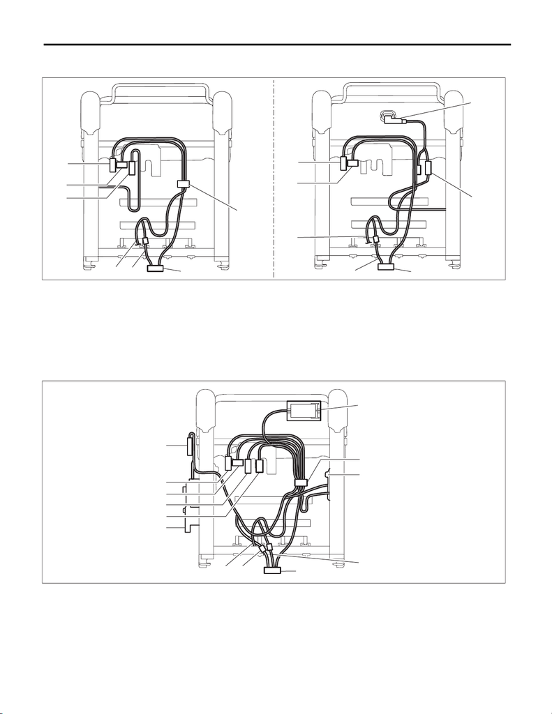

SE-27

Front Seat

SEATS

5) Install connectors located under the front seat.

• Manual seat

• Power seat

6) Install the seat assembly. <Ref. to SE-10, INSTALLATION, Front Seat.>

(A) 6 WAY (B) 4 WAY

(1) Seat cushion heater connector (4) Seat cushion - heater harness (7) Band A

(2) Side airbag connector (5) Backrest heater harness (8) Occupant detection control mod-

ule

(3) Seat belt switch connector (6) Velcro

(1) Power seat switch ASSY (6) Lifter motor (11) Tilt motor

(2) Seat cushion heater connector (7) Seat cushion - heater harness (12) Band A

(3) Side airbag connector (8) Reclining motor harness (13) Slide motor

(4) Seat belt switch connector (9) Velcro

(5) Power seat connector (10) Backrest heater harness

SE-01665

(A) (B)

(1)

(2)

(3)

(6)

(4)

(5)

(7)

(1)

(4)

(6)(5)

(2)

(3)

(8)

SE-01666

(3)

(4)

(5)

(2)

(1)

(7) (8)

(9)

(10)

(11)

(12)

(13)

(6)

15WRX_STI_US_EN.book 27 ページ ２０１５年２月１３日 金曜日 午前１１時２０分

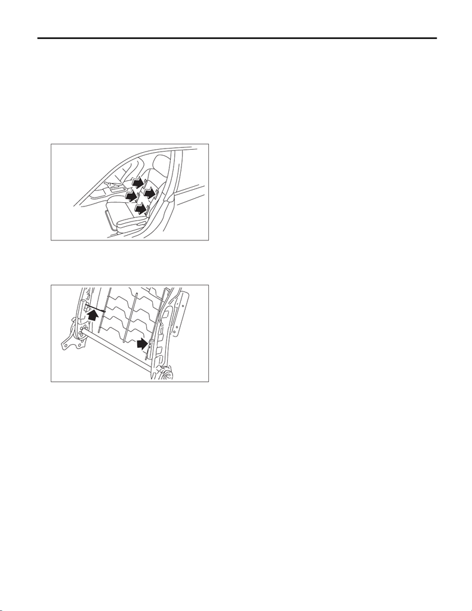

SE-28

Front Seat

SEATS

E: INSPECTION

1. SEAT COVER

Check that there is no tear or fray on the cover COMPL - front backrest and the cover - front cushion.

NOTE:

If the door side of the cover COMPL - front backrest is torn or frayed, the side airbag may not be deployed

properly. In this case, replace the cover COMPL - front backrest with a new part.

2. FLAT MAT HOOK

Check the flat mat hook by applying weight to the backrest assembly.

NOTE:

If the appropriate stiffness is not obtained by applying weight to the backrest assembly, the hook may be dis-

engaged.

If it is due to the deformation of the hook, replace the hook with a new part.

SE-01636

SE-01672

15WRX_STI_US_EN.book 28 ページ ２０１５年２月１３日 金曜日 午前１１時２０分